# Quantium task 2

[figure not shown]

```python
plt.figure(figsize = (15, 8))
plt.plot(combinedsales)
plt.title('Total Sales by Month')
plt.xlabel('Month of Operation')
plt.ylabel('Total Sales')
plt.legend(['Control Sales', 'Control-5%-confi-interval', 'Control-95%-confi-interval', 'Trial Sales'])

# Set new y-axis limit
plt.ylim((0, 1600))

# Highlight trial period
#plt.axvspan(*mdates.datestr2num(['2019-02-01', '2019-04-01']), color = 'grey', alpha = 0.2)

# Set grid
plt.grid()
plt.show()
```

The results show that the trial in store 77 is significantly different to its control store in the trial period as the trial store performance lies outside the 5% to 95% confidence interval of the control store in two of the three trial months.

Let's have a look at assessing this for number of customers as well.

```python
# This would be a repeat of the steps before for total sales

trial_customers = preTrialMeasures.loc[preTrialMeasures['store_type'] == 'Trial Store' , 'CUSTOMERS'].sum()
control_customers = preTrialMeasures.loc[preTrialMeasures['store_type'] == 'Control Store', 'CUSTOMERS'].sum()
scalingFactorCustomers = trial_customers / control_customers
scalingFactorCustomers
```

```
1.0033557046979866
```

```python
scaledControlCustomers = measures
scaledControlCustomers.head(3)
```

|  | STORE_NBR | Year_Month | TOT_SALES | CUSTOMERS | PROD_QTY | Price_Per_Unit | Chip_Per_Txn | Txn_Per_Cust | TransactionMonth |
| --- | --- | --- | --- | --- | --- | --- | --- | --- | --- |
| 0 | 1 | 201807 | 206.9 | 49 | 62 | 3.337097 | 1.192308 | 1.061224 | 2018-07-01 |
| 1 | 1 | 201808 | 176.1 | 42 | 54 | 3.261111 | 1.255814 | 1.023810 | 2018-08-01 |
| 2 | 1 | 201809 | 278.8 | 59 | 75 | 3.717333 | 1.209677 | 1.050847 | 2018-09-01 |

```python
scaledControlCustomers = scaledControlCustomers.loc[scaledControlCustomers['STORE_NBR'] == control_store]
scaledControlCustomers.head(3)
```

|  | STORE_NBR | Year_Month | TOT_SALES | CUSTOMERS | PROD_QTY | Price_Per_Unit | Chip_Per_Txn | Txn_Per_Cust | TransactionMonth |
| --- | --- | --- | --- | --- | --- | --- | --- | --- | --- |
| 2652 | 233 | 201807 | 290.7 | 51 | 88 | 3.303409 | 1.629630 | 1.058824 | 2018-07-01 |
| 2653 | 233 | 201808 | 285.9 | 48 | 80 | 3.573750 | 1.600000 | 1.041667 | 2018-08-01 |
| 2654 | 233 | 201809 | 228.6 | 42 | 70 | 3.265714 | 1.555556 | 1.071429 | 2018-09-01 |

```python
scaledControlCustomers['controlCustomers'] = scaledControlCustomers['CUSTOMERS'] * scalingFactorCustomers
scaledControlCustomers.head(3)
```

|  | STORE_NBR | Year_Month | TOT_SALES | CUSTOMERS | PROD_QTY | Price_Per_Unit | Chip_Per_Txn | Txn_Per_Cust | TransactionMonth | controlCustomers |
| --- | --- | --- | --- | --- | --- | --- | --- | --- | --- | --- |
| 2652 | 233 | 201807 | 290.7 | 51 | 88 | 3.303409 | 1.629630 | 1.058824 | 2018-07-01 | 51.171141 |
| 2653 | 233 | 201808 | 285.9 | 48 | 80 | 3.573750 | 1.600000 | 1.041667 | 2018-08-01 | 48.161074 |
| 2654 | 233 | 201809 | 228.6 | 42 | 70 | 3.265714 | 1.555556 | 1.071429 | 2018-09-01 | 42.140940 |

```python
# Create 'percentageDiff' dataframe
percentageDiff = scaledControlCustomers[['Year_Month', 'controlCustomers']]
percentageDiff.reset_index(drop = True, inplace = True)

# Concatenate with trial store 'nCustomers'
trialCustomers = measures.loc[measures['STORE_NBR'] == trial_store, 'CUSTOMERS']
trialCustomers.reset_index(drop = True, inplace = True)
percentageDiff = pd.concat([percentageDiff, trialCustomers], axis = 1)
percentageDiff.rename(columns = {'CUSTOMERS': 'trialCustomers'}, inplace = True)

percentageDiff.head(3)
```

|  | Year_Month | controlCustomers | trialCustomers |
| --- | --- | --- | --- |
| 0 | 201807 | 51.171141 | 51 |
| 1 | 201808 | 48.161074 | 47 |
| 2 | 201809 | 42.140940 | 42 |

```python
# Calculate percentage difference and put it in a new column

percentageDiff['percentageDiff'] = abs(percentageDiff.controlCustomers - percentageDiff.trialCustomers) / percentageDiff.controlCustomers
percentageDiff.head(3)
```

|  | Year_Month | controlCustomers | trialCustomers | percentageDiff |
| --- | --- | --- | --- | --- |
| 0 | 201807 | 51.171141 | 51 | 0.003344 |
| 1 | 201808 | 48.161074 | 47 | 0.024108 |
| 2 | 201809 | 42.140940 | 42 | 0.003344 |

```python
stdDev = percentageDiff.loc[percentageDiff['Year_Month'] < 201902, 'percentageDiff'].std()
stdDev
```

```
0.01824074855824395
```

```python
degreesOfFreedom = 7
```

```python
percentageDiff['tValue'] = (percentageDiff['percentageDiff'] - 0) / stdDev
percentageDiff.loc[(percentageDiff['Year_Month'] > 201901) & (percentageDiff['Year_Month'] < 201905), 'tValue']
```

[output not shown]

```python
t.isf(0.05, degreesOfFreedom)
```

```
1.8945786050613054
```

```python
controlCustomers = scaledControlCustomers.loc[:, ['TransactionMonth', 'controlCustomers']]
controlCustomers.set_index('TransactionMonth', inplace = True)
controlCustomers.rename(columns = {'controlCustomers': 'Control Customers'}, inplace = True)
controlCustomers.head(3)
```

[output not shown]

```python
trialCustomers = measures.loc[measures['STORE_NBR'] == trial_store, ['TransactionMonth', 'CUSTOMERS']]
trialCustomers.set_index('TransactionMonth', inplace = True)
trialCustomers.rename(columns = {'CUSTOMERS': 'Trial Customers'}, inplace = True)
trialCustomers.head(3)
```

[output not shown]

```python
controlCustomers['Control 5% Confidence Interval'] = controlCustomers['Control Customers'] * (1 - stdDev*2)
controlCustomers['Control 95% Confidence Interval'] = controlCustomers['Control Customers'] * (1 + stdDev*2)
controlCustomers.head(3)
```

[output not shown]

```python
combineCustomers = pd.concat([controlCustomers, trialCustomers], axis = 1)
combineCustomers.head(3)
```

[output not shown]

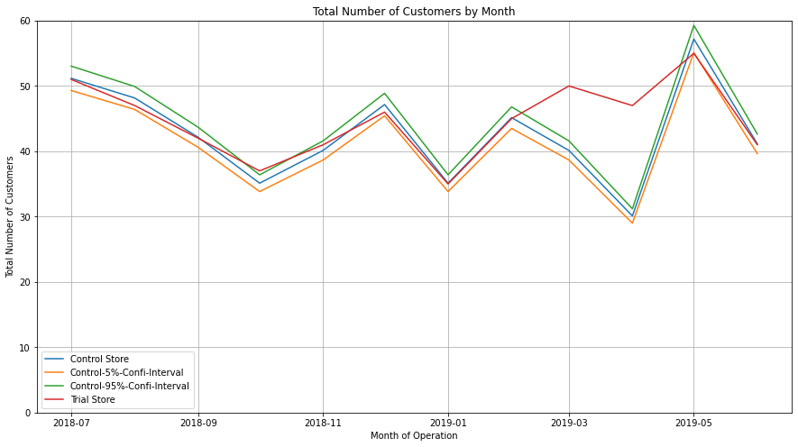

```python
#visualizing
plt.figure(figsize = (15, 8))
plt.plot(combineCustomers)
plt.title('Total Number of Customers by Month')
plt.xlabel('Month of Operation')
plt.ylabel('Total Number of Customers')
plt.legend(['Control Store', 'Control-5%-Confi-Interval', 'Control-95%-Confi-Interval', 'Trial Store'])

plt.ylim((0, 60))
# Highlight trial period
#plt.axvspan(*mdates.datestr2num(['2019-02-01', '2019-04-01']), color = 'grey', alpha = 0.2)

# Set grid
plt.grid()
plt.show()
```

Let's repeat finding the control store and assessing the impact of the trial for each of the other two trial stores 86 and 88.

## Find the control store for trial store 86

```python
trial_store = 86
corr_sale = calcCorr(preTrialMeasures, 'TOT_SALES', trial_store)
corr_cust = calcCorr(preTrialMeasures, 'CUSTOMERS', trial_store)

mag_sale = standardizer(preTrialMeasures, 'TOT_SALES', trial_store)
mag_cust = standardizer(preTrialMeasures, 'CUSTOMERS', trial_store)
```

```python
score_sales = pd.concat([corr_sale, mag_sale['Magnitude']], axis = 1)
score_sales.head(3)
```

|  | Store1 | Store2 | Correlation | Magnitude |
| --- | --- | --- | --- | --- |
| 0 | 86.0 | 1.0 | 0.445632 | 0.488334 |
| 1 | 86.0 | 2.0 | -0.403835 | 0.321131 |
| 2 | 86.0 | 3.0 | -0.261284 | 0.507515 |

```python
score_sales['scoresales'] = 0.5 * corr_sale['Correlation'] + 0.5 * mag_sale['Magnitude']
score_sales.head(3)
```

|  | Store1 | Store2 | Correlation | Magnitude | scoresales |
| --- | --- | --- | --- | --- | --- |
| 0 | 86.0 | 1.0 | 0.445632 | 0.488334 | 0.466983 |
| 1 | 86.0 | 2.0 | -0.403835 | 0.321131 | -0.041352 |
| 2 | 86.0 | 3.0 | -0.261284 | 0.507515 | 0.123116 |

```python
score_custs = pd.concat([corr_cust, mag_cust['Magnitude']], axis = 1)
score_custs['scorecusts'] = 0.5 * corr_cust['Correlation'] + 0.5 * mag_cust['Magnitude']
score_custs.head(3)

score_sales.set_index(['Store1', 'Store2'], inplace = True)
score_custs.set_index(['Store1', 'Store2'], inplace = True)
```

```python
scores_contral = pd.concat([score_sales['scoresales'], score_custs['scorecusts']], axis = 1)
scores_contral.head()
```

| Store1 | Store2 | scoresales | scorecusts |
| --- | --- | --- | --- |
| 86.0 | 1.0 | 0.466983 | 0.498018 |
|  | 2.0 | -0.041352 | 0.171205 |
|  | 3.0 | 0.123116 | 0.104620 |
|  | 4.0 | 0.298309 | 0.184103 |
|  | 5.0 | 0.407497 | 0.230528 |

```python
scores_contral['finalContralScore'] = 0.5 * scores_contral['scoresales'] + 0.5 * scores_contral['scorecusts']
scores_contral.head()
```

| Store1 | Store2 | scoresales | scorecusts | finalContralScore |
| --- | --- | --- | --- | --- |
| 86.0 | 1.0 | 0.466983 | 0.498018 | 0.482500 |
|  | 2.0 | -0.041352 | 0.171205 | 0.064927 |
|  | 3.0 | 0.123116 | 0.104620 | 0.113868 |
|  | 4.0 | 0.298309 | 0.184103 | 0.241206 |
|  | 5.0 | 0.407497 | 0.230528 | 0.319013 |

```python
scores_contral.sort_values(by = 'finalContralScore', ascending = False).head()
```

| Store1 | Store2 | scoresales | scorecusts | finalContralScore |
| --- | --- | --- | --- | --- |
| 86.0 | 155.0 | 0.808106 | 0.733343 | 0.770724 |
|  | 109.0 | 0.697120 | 0.742532 | 0.719826 |
|  | 114.0 | 0.631393 | 0.663384 | 0.647389 |
|  | 225.0 | 0.601841 | 0.684356 | 0.643099 |
|  | 138.0 | 0.593296 | 0.660565 | 0.626930 |

```python
control_store = 155
```

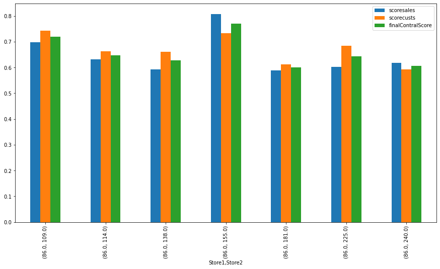

```python
scores_contral[scores_contral.finalContralScore.abs() > 0.6].plot(kind = 'bar', figsize = (15,8))
```

```python
pastSales = preTrialMeasures

store_type = []

for i in pastSales['STORE_NBR']:
    if i == trial_store:
            store_type.append('Trial Store')
    elif i == control_store:
        store_type.append('Control Store')
    else:
        store_type.append('Other Stores')

pastSales['store_type'] = store_type
pastSales.head(3)
```

|  | STORE_NBR | Year_Month | TOT_SALES | CUSTOMERS | PROD_QTY | Price_Per_Unit | Chip_Per_Txn | Txn_Per_Cust | store_type | TransactionMonth |
| --- | --- | --- | --- | --- | --- | --- | --- | --- | --- | --- |
| 0 | 1 | 201807 | 206.9 | 49 | 62 | 3.337097 | 1.192308 | 1.061224 | Other Stores | 2018-07-01 |
| 1 | 1 | 201808 | 176.1 | 42 | 54 | 3.261111 | 1.255814 | 1.023810 | Other Stores | 2018-08-01 |
| 2 | 1 | 201809 | 278.8 | 59 | 75 | 3.717333 | 1.209677 | 1.050847 | Other Stores | 2018-09-01 |

```python
pastSales['TransactionMonth'] = pd.to_datetime(pastSales['Year_Month'].astype(str), format = '%Y%m')
pastSales.head(3)
```

|  | STORE_NBR | Year_Month | TOT_SALES | CUSTOMERS | PROD_QTY | Price_Per_Unit | Chip_Per_Txn | Txn_Per_Cust | store_type | TransactionMonth |
| --- | --- | --- | --- | --- | --- | --- | --- | --- | --- | --- |
| 0 | 1 | 201807 | 206.9 | 49 | 62 | 3.337097 | 1.192308 | 1.061224 | Other Stores | 2018-07-01 |
| 1 | 1 | 201808 | 176.1 | 42 | 54 | 3.261111 | 1.255814 | 1.023810 | Other Stores | 2018-08-01 |
| 2 | 1 | 201809 | 278.8 | 59 | 75 | 3.717333 | 1.209677 | 1.050847 | Other Stores | 2018-09-01 |

```python
controlSalesPlot = pastSales.loc[pastSales['store_type'] == 'Control Store', ['TransactionMonth', 'TOT_SALES']]
controlSalesPlot.set_index('TransactionMonth', inplace = True)
controlSalesPlot.rename(columns = {'TOT_SALES': 'Control Store'}, inplace = True)

trialSalesPlot = pastSales.loc[pastSales['store_type'] == 'Trial Store', ['TransactionMonth', 'TOT_SALES']]
trialSalesPlot.set_index('TransactionMonth', inplace = True)
trialSalesPlot.rename(columns = {'TOT_SALES': 'Trial Store'}, inplace = True)

otherSalesPlot = pastSales.loc[pastSales['store_type'] == 'Other Stores', ['TransactionMonth', 'TOT_SALES']]
otherSalesPlot = pd.DataFrame(otherSalesPlot.groupby('TransactionMonth').TOT_SALES.mean())
otherSalesPlot.rename(columns = {'TOT_SALES': 'Other Stores'}, inplace = True)

combineSalesPlot = pd.concat([controlSalesPlot, trialSalesPlot, otherSalesPlot], axis = 1)
combineSalesPlot
```

| TransactionMonth | Control Store | Trial Store | Other Stores |
| --- | --- | --- | --- |
| 2018-07-01 | 924.6 | 892.20 | 633.239922 |
| 2018-08-01 | 782.7 | 764.05 | 606.326744 |
| 2018-09-01 | 1014.4 | 914.60 | 614.480620 |
| 2018-10-01 | 963.8 | 948.40 | 629.415504 |
| 2018-11-01 | 898.8 | 918.00 | 613.593411 |
| 2018-12-01 | 849.8 | 841.20 | 644.020155 |
| 2019-01-01 | 874.6 | 841.40 | 623.513566 |

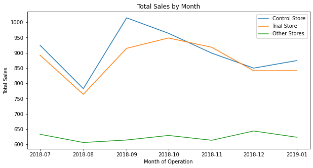

```python
plt.figure(figsize = (10, 5))
plt.plot(combineSalesPlot)
plt.title('Total Sales by Month')
plt.xlabel('Month of Operation')
plt.ylabel('Total Sales')
plt.legend(['Control Store', 'Trial Store', 'Other Stores'])
```

```python
# Do the same for CUSTOMERS
controlCustomersPlot = pastSales.loc[pastSales['store_type'] == 'Control Store', ['TransactionMonth', 'CUSTOMERS']]
controlCustomersPlot.set_index('TransactionMonth', inplace = True)
controlCustomersPlot.rename(columns = {'CUSTOMERS': 'Control Store'}, inplace = True)

trialCustomersPlot = pastSales.loc[pastSales['store_type'] == 'Trial Store', ['TransactionMonth', 'CUSTOMERS']]
trialCustomersPlot.set_index('TransactionMonth', inplace = True)
trialCustomersPlot.rename(columns = {'CUSTOMERS': 'Trial Store'}, inplace = True)

otherCustomersPlot = pastSales.loc[pastSales['store_type'] == 'Other Stores', ['TransactionMonth', 'CUSTOMERS']]
otherCustomersPlot = pd.DataFrame(otherCustomersPlot.groupby('TransactionMonth').CUSTOMERS.mean())
otherCustomersPlot.rename(columns = {'CUSTOMERS': 'Other Stores'}, inplace = True)

# Concatenate
combineCustomersPlot = pd.concat([controlCustomersPlot, trialCustomersPlot, otherCustomersPlot], axis = 1)
combineCustomersPlot
```

| TransactionMonth | Control Store | Trial Store | Other Stores |
| --- | --- | --- | --- |
| 2018-07-01 | 101 | 99 | 71.953488 |
| 2018-08-01 | 91 | 94 | 71.771318 |
| 2018-09-01 | 103 | 103 | 69.658915 |
| 2018-10-01 | 108 | 109 | 71.046512 |
| 2018-11-01 | 101 | 100 | 70.069767 |
| 2018-12-01 | 97 | 98 | 73.120155 |
| 2019-01-01 | 96 | 94 | 70.775194 |

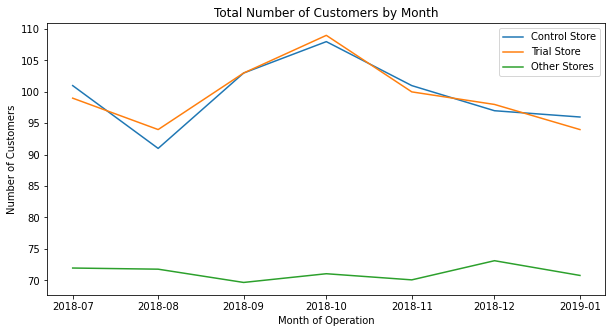

```python
# Plot total number of customers for all 3 types of stores

plt.figure(figsize = (10, 5))
plt.plot(combineCustomersPlot)
plt.title('Total Number of Customers by Month')
plt.xlabel('Month of Operation')
plt.ylabel('Number of Customers')
plt.legend(['Control Store', 'Trial Store', 'Other Stores'])
```

# Assessment of trial for trial store 86

```python
a = preTrialMeasures.loc[preTrialMeasures['store_type'] == 'Trial Store']

b = preTrialMeasures.loc[preTrialMeasures['store_type'] == 'Control Store']


scalingFactorSales = a['TOT_SALES'].sum() / b['TOT_SALES'].sum()

scalingFactorSales
```

```
0.9700651481287746
```

```python
scaledControlSales = measures.loc[measures['STORE_NBR'] == control_store]

# Create 'controlSales' which applies 'scalingFactorSales' to 'totSales' column

scaledControlSales['controlSales'] = scaledControlSales['TOT_SALES'] * scalingFactorSales
scaledControlSales.head(3)
```

|  | STORE_NBR | Year_Month | TOT_SALES | CUSTOMERS | PROD_QTY | Price_Per_Unit | Chip_Per_Txn | Txn_Per_Cust | TransactionMonth | controlSales |
| --- | --- | --- | --- | --- | --- | --- | --- | --- | --- | --- |
| 1764 | 155 | 201807 | 924.6 | 101 | 250 | 3.698400 | 2.032520 | 1.217822 | 2018-07-01 | 896.922236 |
| 1765 | 155 | 201808 | 782.7 | 91 | 229 | 3.417904 | 1.924370 | 1.307692 | 2018-08-01 | 759.269991 |
| 1766 | 155 | 201809 | 1014.4 | 103 | 290 | 3.497931 | 2.013889 | 1.398058 | 2018-09-01 | 984.034086 |

```python
# Create 'percentageDiff' dataframe
percentageDiff = scaledControlSales[['Year_Month', 'controlSales']]
percentageDiff.reset_index(drop = True, inplace = True)

# Concatenate with trial store 'totSales'
trialSales = measures.loc[measures['STORE_NBR'] == trial_store, 'TOT_SALES']
trialSales.reset_index(drop = True, inplace = True)
percentageDiff = pd.concat([percentageDiff, trialSales], axis = 1)
percentageDiff.rename(columns = {'TOT_SALES': 'trialSales'}, inplace = True)

percentageDiff['percentageDiff'] = abs(percentageDiff.controlSales - percentageDiff.trialSales) / percentageDiff.controlSales
percentageDiff.head(3)
```

|  | Year_Month | controlSales | trialSales | percentageDiff |
| --- | --- | --- | --- | --- |
| 0 | 201807 | 896.922236 | 892.20 | 0.005265 |
| 1 | 201808 | 759.269991 | 764.05 | 0.006296 |
| 2 | 201809 | 984.034086 | 914.60 | 0.070561 |

```python
stdDev = percentageDiff.loc[percentageDiff['Year_Month'] < 201902, 'percentageDiff'].std()
stdDev
```

```
0.025833952854772586
```

```python
degreesOfFreedom = 7
t.isf(0.05, degreesOfFreedom)
```

```
1.8945786050613054
```

```python
# Add a new column 'TransactionMonth' to 'scaledControlSales'

scaledControlSales['TransactionMonth'] = pd.to_datetime(scaledControlSales['Year_Month'].astype(str), format = '%Y%m')
scaledControlSales.head(3)
```

|  | STORE_NBR | Year_Month | TOT_SALES | CUSTOMERS | PROD_QTY | Price_Per_Unit | Chip_Per_Txn | Txn_Per_Cust | TransactionMonth | controlSales |
| --- | --- | --- | --- | --- | --- | --- | --- | --- | --- | --- |
| 1764 | 155 | 201807 | 924.6 | 101 | 250 | 3.698400 | 2.032520 | 1.217822 | 2018-07-01 | 896.922236 |
| 1765 | 155 | 201808 | 782.7 | 91 | 229 | 3.417904 | 1.924370 | 1.307692 | 2018-08-01 | 759.269991 |
| 1766 | 155 | 201809 | 1014.4 | 103 | 290 | 3.497931 | 2.013889 | 1.398058 | 2018-09-01 | 984.034086 |

```python
# Extract 'controlSales' from 'scaledControlSales' dataframe for control store

controlSales = scaledControlSales.loc[:, ['TransactionMonth', 'controlSales']]
controlSales.set_index('TransactionMonth', inplace = True)
controlSales.rename(columns = {'controlSales': 'Control Sales'}, inplace = True)
controlSales.head(3)
```

| TransactionMonth | Control Sales |
| --- | --- |
| 2018-07-01 | 896.922236 |
| 2018-08-01 | 759.269991 |
| 2018-09-01 | 984.034086 |

```python
# Create a new column 'TransationMonth' under 'measures' dataframe

measures['TransactionMonth'] = pd.to_datetime(measures['Year_Month'].astype(str), format = '%Y%m')
measures.head(3)
```

|  | STORE_NBR | Year_Month | TOT_SALES | CUSTOMERS | PROD_QTY | Price_Per_Unit | Chip_Per_Txn | Txn_Per_Cust | TransactionMonth |
| --- | --- | --- | --- | --- | --- | --- | --- | --- | --- |
| 0 | 1 | 201807 | 206.9 | 49 | 62 | 3.337097 | 1.192308 | 1.061224 | 2018-07-01 |
| 1 | 1 | 201808 | 176.1 | 42 | 54 | 3.261111 | 1.255814 | 1.023810 | 2018-08-01 |
| 2 | 1 | 201809 | 278.8 | 59 | 75 | 3.717333 | 1.209677 | 1.050847 | 2018-09-01 |

```python
# Extract 'TOT_SALES' for trial store from 'measures'

trialSales = measures.loc[measures['STORE_NBR'] == trial_store, ['TransactionMonth', 'TOT_SALES']]
trialSales.set_index('TransactionMonth', inplace = True)
trialSales.rename(columns = {'TOT_SALES': 'Trial Sales'}, inplace = True)
trialSales.head(3)
```

| TransactionMonth | Trial Sales |
| --- | --- |
| 2018-07-01 | 892.20 |
| 2018-08-01 | 764.05 |
| 2018-09-01 | 914.60 |

```python
# Create two new columns under 'controlSales' which calculates the 5% and 95% confidence interval

controlSales['Control 5% Confidence Interval'] = controlSales['Control Sales'] * (1 - stdDev*2)
controlSales['Control 95% Confidence Interval'] = controlSales['Control Sales'] * (1 + stdDev*2)

combinedsales = pd.concat([controlSales, trialSales], axis = 1)
combinedsales.head(3)
```

| TransactionMonth | Control Sales | Control 5% Confidence Interval | Control 95% Confidence Interval | Trial Sales |
| --- | --- | --- | --- | --- |
| 2018-07-01 | 896.922236 | 850.580142 | 943.264329 | 892.20 |
| 2018-08-01 | 759.269991 | 720.040101 | 798.499882 | 764.05 |
| 2018-09-01 | 984.034086 | 933.191106 | 1034.877067 | 914.60 |

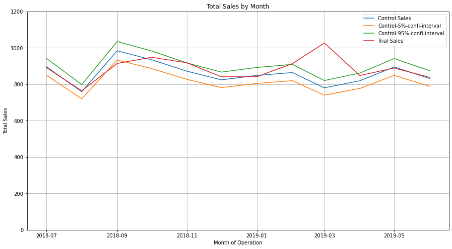

```python
plt.figure(figsize = (15, 8))
plt.plot(combinedsales)
plt.title('Total Sales by Month')
plt.xlabel('Month of Operation')
plt.ylabel('Total Sales')
plt.legend(['Control Sales', 'Control-5%-confi-interval', 'Control-95%-confi-interval', 'Trial Sales'])

# Set new y-axis limit
plt.ylim((0, 1200))

# Highlight trial period
#plt.axvspan(*mdates.datestr2num(['2019-02-01', '2019-04-01']), color = 'grey', alpha = 0.2)

# Set grid
plt.grid()
#plt.show()
```

The results show that the trial in store 86 is not significantly different to its control store in the trial period. The trial store performance lies inside the 5% to 95% confidence interval of the control store in two of the three trial months.

```python
# This would be a repeat of the steps before for total sales

trial_customers = preTrialMeasures.loc[preTrialMeasures['store_type'] == 'Trial Store' , 'CUSTOMERS'].sum()
control_customers = preTrialMeasures.loc[preTrialMeasures['store_type'] == 'Control Store', 'CUSTOMERS'].sum()
scalingFactorCustomers = trial_customers / control_customers
scalingFactorCustomers
```

```
1.0
```

```python
scaledControlCustomers = measures
scaledControlCustomers = scaledControlCustomers.loc[scaledControlCustomers['STORE_NBR'] == control_store]
scaledControlCustomers['controlCustomers'] = scaledControlCustomers['CUSTOMERS'] * scalingFactorCustomers
scaledControlCustomers.head(3)
```

|  | STORE_NBR | Year_Month | TOT_SALES | CUSTOMERS | PROD_QTY | Price_Per_Unit | Chip_Per_Txn | Txn_Per_Cust | TransactionMonth | controlCustomers |
| --- | --- | --- | --- | --- | --- | --- | --- | --- | --- | --- |
| 1764 | 155 | 201807 | 924.6 | 101 | 250 | 3.698400 | 2.032520 | 1.217822 | 2018-07-01 | 101.0 |
| 1765 | 155 | 201808 | 782.7 | 91 | 229 | 3.417904 | 1.924370 | 1.307692 | 2018-08-01 | 91.0 |
| 1766 | 155 | 201809 | 1014.4 | 103 | 290 | 3.497931 | 2.013889 | 1.398058 | 2018-09-01 | 103.0 |

```python
# Create 'percentageDiff' dataframe
percentageDiff = scaledControlCustomers[['Year_Month', 'controlCustomers']]
percentageDiff.reset_index(drop = True, inplace = True)

# Concatenate with trial store 'nCustomers'
trialCustomers = measures.loc[measures['STORE_NBR'] == trial_store, 'CUSTOMERS']
trialCustomers.reset_index(drop = True, inplace = True)
percentageDiff = pd.concat([percentageDiff, trialCustomers], axis = 1)
percentageDiff.rename(columns = {'CUSTOMERS': 'trialCustomers'}, inplace = True)


# Calculate percentage difference and put it in a new column

percentageDiff['percentageDiff'] = abs(percentageDiff.controlCustomers - percentageDiff.trialCustomers) / percentageDiff.controlCustomers

percentageDiff.head(3)
```

|  | Year_Month | controlCustomers | trialCustomers | percentageDiff |
| --- | --- | --- | --- | --- |
| 0 | 201807 | 101.0 | 99 | 0.019802 |
| 1 | 201808 | 91.0 | 94 | 0.032967 |
| 2 | 201809 | 103.0 | 103 | 0.000000 |

```python
controlCustomers = scaledControlCustomers.loc[:, ['TransactionMonth', 'controlCustomers']]
controlCustomers.set_index('TransactionMonth', inplace = True)
controlCustomers.rename(columns = {'controlCustomers': 'Control Customers'}, inplace = True)
print(controlCustomers.head(3))

trialCustomers = measures.loc[measures['STORE_NBR'] == trial_store, ['TransactionMonth', 'CUSTOMERS']]
trialCustomers.set_index('TransactionMonth', inplace = True)
trialCustomers.rename(columns = {'CUSTOMERS': 'Trial Customers'}, inplace = True)
print(trialCustomers.head(3))
```

```
                  Control Customers
TransactionMonth
2018-07-01                    101.0
2018-08-01                     91.0
2018-09-01                    103.0
                  Trial Customers
TransactionMonth
2018-07-01                     99
2018-08-01                     94
2018-09-01                    103
```

```python
controlCustomers['Control 5% Confidence Interval'] = controlCustomers['Control Customers'] * (1 - stdDev*2)
controlCustomers['Control 95% Confidence Interval'] = controlCustomers['Control Customers'] * (1 + stdDev*2)
controlCustomers.head(3)
```

| TransactionMonth | Control Customers | Control 5% Confidence Interval | Control 95% Confidence Interval |
| --- | --- | --- | --- |
| 2018-07-01 | 101.0 | 95.781542 | 106.218458 |
| 2018-08-01 | 91.0 | 86.298221 | 95.701779 |
| 2018-09-01 | 103.0 | 97.678206 | 108.321794 |

```python
combineCustomers = pd.concat([controlCustomers, trialCustomers], axis = 1)
combineCustomers.head(3)
```

| TransactionMonth | Control Customers | Control 5% Confidence Interval | Control 95% Confidence Interval | Trial Customers |
| --- | --- | --- | --- | --- |
| 2018-07-01 | 101.0 | 95.781542 | 106.218458 | 99 |
| 2018-08-01 | 91.0 | 86.298221 | 95.701779 | 94 |
| 2018-09-01 | 103.0 | 97.678206 | 108.321794 | 103 |

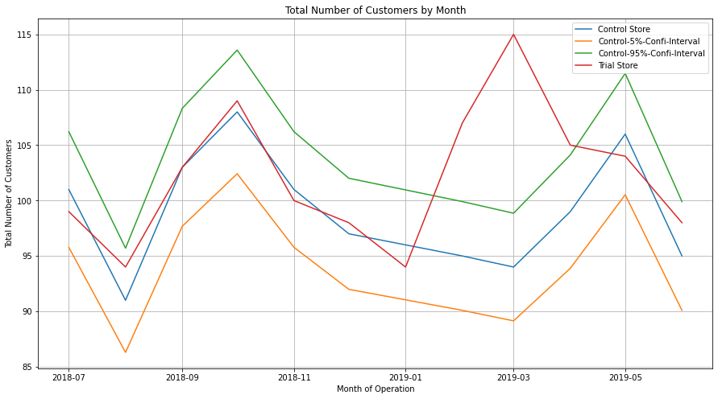

```python
#visualizing
plt.figure(figsize = (15, 8))
plt.plot(combineCustomers)
plt.title('Total Number of Customers by Month')
plt.xlabel('Month of Operation')
plt.ylabel('Total Number of Customers')
plt.legend(['Control Store', 'Control-5%-Confi-Interval', 'Control-95%-Confi-Interval', 'Trial Store'])

#plt.ylim((0, 120))
# Highlight trial period
#plt.axvspan(*mdates.datestr2num(['2019-02-01', '2019-04-01']), color = 'grey', alpha = 0.2)

# Set grid
plt.grid()
plt.show()
```

It looks like the number of customers is significantly higher in all of the three months. This seems to suggest that the trial had a significant impact on increasing the number of customers in trial store 86 but as we saw, sales were not significantly higher. We should check with the Category Manager if there were special deals in the trial store that were may have resulted in lower prices, impacting the results.

# Find control store for trial store 88

```python
trial_store = 88
corr_sale = calcCorr(preTrialMeasures, 'TOT_SALES', trial_store)
corr_cust = calcCorr(preTrialMeasures, 'CUSTOMERS', trial_store)

mag_sale = standardizer(preTrialMeasures, 'TOT_SALES', trial_store)
mag_cust = standardizer(preTrialMeasures, 'CUSTOMERS', trial_store)

score_sales = pd.concat([corr_sale, mag_sale['Magnitude']], axis = 1)
score_sales['scoresales'] = 0.5 * corr_sale['Correlation'] + 0.5 * mag_sale['Magnitude']
score_sales.head(3)
```

|  | Store1 | Store2 | Correlation | Magnitude | scoresales |
| --- | --- | --- | --- | --- | --- |
| 0 | 88.0 | 1.0 | 0.813636 | 0.548959 | 0.681297 |
| 1 | 88.0 | 2.0 | -0.067927 | 0.541212 | 0.236643 |
| 2 | 88.0 | 3.0 | -0.507847 | 0.458109 | -0.024869 |

```python
score_custs = pd.concat([corr_cust, mag_cust['Magnitude']], axis = 1)
score_custs['scorecusts'] = 0.5 * corr_cust['Correlation'] + 0.5 * mag_cust['Magnitude']
score_custs.head(3)
```

|  | Store1 | Store2 | Correlation | Magnitude | scorecusts |
| --- | --- | --- | --- | --- | --- |
| 0 | 88.0 | 1.0 | 0.305334 | 0.357143 | 0.331238 |
| 1 | 88.0 | 2.0 | -0.452379 | 0.285714 | -0.083332 |
| 2 | 88.0 | 3.0 | 0.522884 | 0.683673 | 0.603279 |

```python
#score_sales.set_index(['Store1', 'Store2'], inplace = True)
#score_custs.set_index(['Store1', 'Store2'], inplace = True)

scores_contral = pd.concat([score_sales['scoresales'], score_custs['scorecusts']], axis = 1)
scores_contral.head()
```

| Store1 | Store2 | scoresales | scorecusts |
| --- | --- | --- | --- |
| 88.0 | 1.0 | 0.681297 | 0.331238 |
|  | 2.0 | 0.236643 | -0.083332 |
|  | 3.0 | -0.024869 | 0.603279 |
|  | 4.0 | -0.130559 | 0.108210 |
|  | 5.0 | 0.343370 | 0.266561 |

```python
scores_contral['finalContralScore'] = 0.5 * scores_contral['scoresales'] + 0.5 * scores_contral['scorecusts']
scores_contral.head(3)
```

| Store1 | Store2 | scoresales | scorecusts | finalContralScore |
| --- | --- | --- | --- | --- |
| 88.0 | 1.0 | 0.681297 | 0.331238 | 0.506268 |
|  | 2.0 | 0.236643 | -0.083332 | 0.076655 |
|  | 3.0 | -0.024869 | 0.603279 | 0.289205 |

```python
scores_contral.sort_values(by = 'finalContralScore', ascending = False).head()
```

| Store1 | Store2 | scoresales | scorecusts | finalContralScore |
| --- | --- | --- | --- | --- |
| 88.0 | 178.0 | 0.650803 | 0.707828 | 0.679316 |
|  | 14.0 | 0.646064 | 0.685774 | 0.665919 |
|  | 134.0 | 0.775084 | 0.540154 | 0.657619 |
|  | 237.0 | 0.451974 | 0.777235 | 0.614604 |
|  | 187.0 | 0.616752 | 0.594560 | 0.605656 |

shows that stores 178,14,134 are the most correlated to store 88

### Visualize

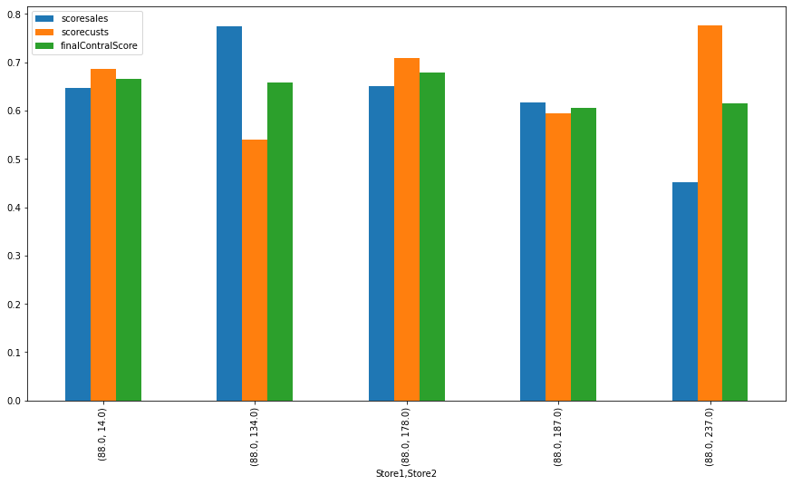

```python
scores_contral[scores_contral.finalContralScore.abs() > 0.6].plot(kind = 'bar', figsize = (15,8))
```

```python
trial_store = 88
trial_totsales = measures.loc[measures['STORE_NBR'] == trial_store, ['TransactionMonth', 'TOT_SALES']]
store14 = measures.loc[measures['STORE_NBR'] == 14, ['TransactionMonth', 'TOT_SALES']]

trial_totsales.set_index(['TransactionMonth'], inplace = True)
trial_totsales = trial_totsales.rename(columns = {'TOT_SALES': 'Trial TOT SALES'})
store14.set_index(['TransactionMonth'], inplace = True)
```

```python
trialand14 = pd.concat([trial_totsales, store14['TOT_SALES']], axis = 1)
trialand14
```

| TransactionMonth | Trial TOT SALES | TOT_SALES |
| --- | --- | --- |
| 2018-07-01 | 1310.00 | 952.0 |
| 2018-08-01 | 1323.80 | 915.5 |
| 2018-09-01 | 1423.00 | 954.4 |
| 2018-10-01 | 1352.40 | 962.6 |
| 2018-11-01 | 1382.80 | 975.6 |
| 2018-12-01 | 1325.20 | 947.2 |
| 2019-01-01 | 1266.40 | 837.2 |
| 2019-02-01 | 1370.20 | 1088.8 |
| 2019-03-01 | 1477.20 | 998.8 |
| 2019-04-01 | 1439.40 | 1059.8 |
| 2019-05-01 | 1308.25 | 888.0 |
| 2019-06-01 | 1354.60 | 722.6 |

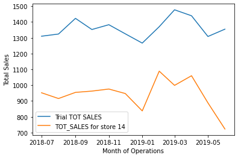

```python
plt.plot(trialand14)
plt.xlabel('Month of Operations')
plt.ylabel('Total Sales')
plt.legend(['Trial TOT SALES', 'TOT_SALES for store 14'])
```

```python
trial_store = 88
trial_totsales = measures.loc[measures['STORE_NBR'] == trial_store, ['TransactionMonth', 'TOT_SALES']]
store178 = measures.loc[measures['STORE_NBR'] == 178, ['TransactionMonth', 'TOT_SALES']]

trial_totsales.set_index(['TransactionMonth'], inplace = True)
trial_totsales = trial_totsales.rename(columns = {'TOT_SALES': 'Trial TOT SALES'})
store178.set_index(['TransactionMonth'], inplace = True)

trialand178 = pd.concat([trial_totsales, store178['TOT_SALES']], axis = 1)
trialand178
```

[output not shown]

[figure not shown]

```python
plt.plot(trialand178)
plt.xlabel('Month of Operations')
plt.ylabel('Total Sales')
plt.legend(['Trial TOT SALES', 'TOT_SALES for store 178'])
```

```python
trial_store = 88
trial_totsales = measures.loc[measures['STORE_NBR'] == trial_store, ['TransactionMonth', 'TOT_SALES']]
store134 = measures.loc[measures['STORE_NBR'] == 134, ['TransactionMonth', 'TOT_SALES']]

trial_totsales.set_index(['TransactionMonth'], inplace = True)
trial_totsales = trial_totsales.rename(columns = {'TOT_SALES': 'Trial TOT SALES'})
store134.set_index(['TransactionMonth'], inplace = True)

trialand134 = pd.concat([trial_totsales, store134['TOT_SALES']], axis = 1)
trialand134
```

| TransactionMonth | Trial TOT SALES | TOT_SALES |
| --- | --- | --- |
| 2018-07-01 | 1310.00 | 419.20 |
| 2018-08-01 | 1323.80 | 432.65 |
| 2018-09-01 | 1423.00 | 463.80 |
| 2018-10-01 | 1352.40 | 473.40 |
| 2018-11-01 | 1382.80 | 467.60 |
| 2018-12-01 | 1325.20 | 413.40 |
| 2019-01-01 | 1266.40 | 384.20 |
| 2019-02-01 | 1370.20 | 347.60 |
| 2019-03-01 | 1477.20 | 388.60 |
| 2019-04-01 | 1439.40 | 594.60 |
| 2019-05-01 | 1308.25 | 407.10 |
| 2019-06-01 | 1354.60 | 454.20 |

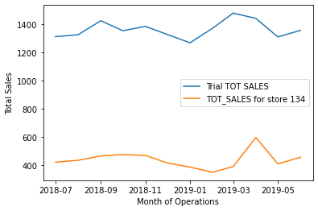

```python
plt.plot(trialand134)
plt.xlabel('Month of Operations')
plt.ylabel('Total Sales')
plt.legend(['Trial TOT SALES', 'TOT_SALES for store 134'])
```

```python
trial_store = 88
trial_totsales = measures.loc[measures['STORE_NBR'] == trial_store, ['TransactionMonth', 'TOT_SALES']]
store237 = measures.loc[measures['STORE_NBR'] == 237, ['TransactionMonth', 'TOT_SALES']]

trial_totsales.set_index(['TransactionMonth'], inplace = True)
trial_totsales = trial_totsales.rename(columns = {'TOT_SALES': 'Trial TOT SALES'})
store237.set_index(['TransactionMonth'], inplace = True)

trialand237 = pd.concat([trial_totsales, store237['TOT_SALES']], axis = 1)
trialand237
```

| TransactionMonth | Trial TOT SALES | TOT_SALES |
| --- | --- | --- |
| 2018-07-01 | 1310.00 | 1448.4 |
| 2018-08-01 | 1323.80 | 1367.8 |
| 2018-09-01 | 1423.00 | 1322.2 |
| 2018-10-01 | 1352.40 | 1348.3 |
| 2018-11-01 | 1382.80 | 1397.6 |
| 2018-12-01 | 1325.20 | 1265.0 |
| 2019-01-01 | 1266.40 | 1219.7 |
| 2019-02-01 | 1370.20 | 1404.8 |
| 2019-03-01 | 1477.20 | 1208.2 |
| 2019-04-01 | 1439.40 | 1204.6 |
| 2019-05-01 | 1308.25 | 1199.3 |
| 2019-06-01 | 1354.60 | 1153.6 |

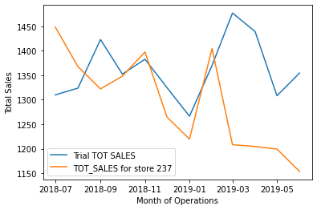

```python
plt.plot(trialand237)
plt.xlabel('Month of Operations')
plt.ylabel('Total Sales')
plt.legend(['Trial TOT SALES', 'TOT_SALES for store 237'])
```

By the above visualizations, we can see that store 237 has the most similar distributions as trial store 88. Therefore, we select store 237 as control store.

```python
control_store = 237
```

## Visualizing

```python
pastSales = preTrialMeasures

store_type = []

for i in pastSales['STORE_NBR']:
    if i == trial_store:
            store_type.append('Trial Store')
    elif i == control_store:
        store_type.append('Control Store')
    else:
        store_type.append('Other Stores')

pastSales['store_type'] = store_type
pastSales['TransactionMonth'] = pd.to_datetime(pastSales['Year_Month'].astype(str), format = '%Y%m')
pastSales.head(3)
```

|  | STORE_NBR | Year_Month | TOT_SALES | CUSTOMERS | PROD_QTY | Price_Per_Unit | Chip_Per_Txn | Txn_Per_Cust | store_type | TransactionMonth |
| --- | --- | --- | --- | --- | --- | --- | --- | --- | --- | --- |
| 0 | 1 | 201807 | 206.9 | 49 | 62 | 3.337097 | 1.192308 | 1.061224 | Other Stores | 2018-07-01 |
| 1 | 1 | 201808 | 176.1 | 42 | 54 | 3.261111 | 1.255814 | 1.023810 | Other Stores | 2018-08-01 |
| 2 | 1 | 201809 | 278.8 | 59 | 75 | 3.717333 | 1.209677 | 1.050847 | Other Stores | 2018-09-01 |

```python
# First create relevant dataframes

controlSalesPlot = pastSales.loc[pastSales['store_type'] == 'Control Store', ['TransactionMonth', 'TOT_SALES']]
controlSalesPlot.set_index('TransactionMonth', inplace = True)
controlSalesPlot.rename(columns = {'TOT_SALES': 'Control Store'}, inplace = True)

trialSalesPlot = pastSales.loc[pastSales['store_type'] == 'Trial Store', ['TransactionMonth', 'TOT_SALES']]
trialSalesPlot.set_index('TransactionMonth', inplace = True)
trialSalesPlot.rename(columns = {'TOT_SALES': 'Trial Store'}, inplace = True)

otherSalesPlot = pastSales.loc[pastSales['store_type'] == 'Other Stores', ['TransactionMonth', 'TOT_SALES']]
otherSalesPlot = pd.DataFrame(otherSalesPlot.groupby('TransactionMonth').TOT_SALES.mean())
otherSalesPlot.rename(columns = {'TOT_SALES': 'Other Stores'}, inplace = True)

combineSalesPlot = pd.concat([controlSalesPlot, trialSalesPlot, otherSalesPlot], axis = 1)
combineSalesPlot
```

| TransactionMonth | Control Store | Trial Store | Other Stores |
| --- | --- | --- | --- |
| 2018-07-01 | 1448.4 | 1310.0 | 629.590310 |
| 2018-08-01 | 1367.8 | 1323.8 | 601.889341 |
| 2018-09-01 | 1322.2 | 1423.0 | 611.317054 |
| 2018-10-01 | 1348.3 | 1352.4 | 626.359302 |
| 2018-11-01 | 1397.6 | 1382.8 | 609.858527 |
| 2018-12-01 | 1265.0 | 1325.2 | 640.534884 |
| 2019-01-01 | 1219.7 | 1266.4 | 620.528682 |

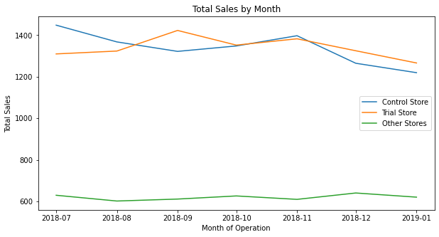

```python
# Plot total sales by month for all 3 types of stores

plt.figure(figsize = (10, 5))
plt.plot(combineSalesPlot)
plt.title('Total Sales by Month')
plt.xlabel('Month of Operation')
plt.ylabel('Total Sales')
plt.legend(['Control Store', 'Trial Store', 'Other Stores'], loc = 5)
```

```python
# Do the same for CUSTOMERS
controlCustomersPlot = pastSales.loc[pastSales['store_type'] == 'Control Store', ['TransactionMonth', 'CUSTOMERS']]
controlCustomersPlot.set_index('TransactionMonth', inplace = True)
controlCustomersPlot.rename(columns = {'CUSTOMERS': 'Control Store'}, inplace = True)

trialCustomersPlot = pastSales.loc[pastSales['store_type'] == 'Trial Store', ['TransactionMonth', 'CUSTOMERS']]
trialCustomersPlot.set_index('TransactionMonth', inplace = True)
trialCustomersPlot.rename(columns = {'CUSTOMERS': 'Trial Store'}, inplace = True)

otherCustomersPlot = pastSales.loc[pastSales['store_type'] == 'Other Stores', ['TransactionMonth', 'CUSTOMERS']]
otherCustomersPlot = pd.DataFrame(otherCustomersPlot.groupby('TransactionMonth').CUSTOMERS.mean())
otherCustomersPlot.rename(columns = {'CUSTOMERS': 'Other Stores'}, inplace = True)

# Concatenate
combineCustomersPlot = pd.concat([controlCustomersPlot, trialCustomersPlot, otherCustomersPlot], axis = 1)
combineCustomersPlot
```

| TransactionMonth | Control Store | Trial Store | Other Stores |
| --- | --- | --- | --- |
| 2018-07-01 | 128 | 129 | 71.732558 |
| 2018-08-01 | 135 | 131 | 71.457364 |
| 2018-09-01 | 126 | 124 | 69.488372 |
| 2018-10-01 | 123 | 123 | 70.934109 |
| 2018-11-01 | 132 | 130 | 69.833333 |
| 2018-12-01 | 124 | 126 | 72.906977 |
| 2019-01-01 | 117 | 117 | 70.604651 |

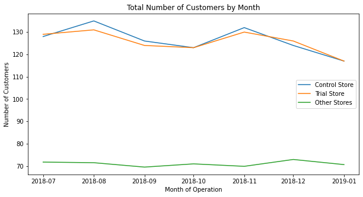

```python
# Plot total number of customers for all 3 types of stores

plt.figure(figsize = (10, 5))
plt.plot(combineCustomersPlot)
plt.title('Total Number of Customers by Month')
plt.xlabel('Month of Operation')
plt.ylabel('Number of Customers')
plt.legend(['Control Store', 'Trial Store', 'Other Stores'], loc = 5)
```

# Assessment of trial for trial store 88

The trial period goes from the start of February 2019 to April 2019. We now want to see if there has been an uplift in overall chip sales.

We'll start with scaling the control store's sales to a level similar to control for any differences between the two stores outside of the trial period.

```python
a = preTrialMeasures.loc[preTrialMeasures['store_type'] == 'Trial Store']

b = preTrialMeasures.loc[preTrialMeasures['store_type'] == 'Control Store']


scalingFactorSales = a['TOT_SALES'].sum() / b['TOT_SALES'].sum()

scalingFactorSales
```

```
1.0015583306649594
```

```python
scaledControlSales = measures.loc[measures['STORE_NBR'] == control_store]
scaledControlSales.head(3)
```

|  | STORE_NBR | Year_Month | TOT_SALES | CUSTOMERS | PROD_QTY | Price_Per_Unit | Chip_Per_Txn | Txn_Per_Cust | TransactionMonth |
| --- | --- | --- | --- | --- | --- | --- | --- | --- | --- |
| 2700 | 237 | 201807 | 1448.4 | 128 | 324 | 4.470370 | 2.000000 | 1.265625 | 2018-07-01 |
| 2701 | 237 | 201808 | 1367.8 | 135 | 313 | 4.369968 | 1.896970 | 1.222222 | 2018-08-01 |
| 2702 | 237 | 201809 | 1322.2 | 126 | 299 | 4.422074 | 2.006711 | 1.182540 | 2018-09-01 |

```python
scaledControlSales['controlSales'] = scaledControlSales['TOT_SALES'] * scalingFactorSales
scaledControlSales.head(3)
```

|  | STORE_NBR | Year_Month | TOT_SALES | CUSTOMERS | PROD_QTY | Price_Per_Unit | Chip_Per_Txn | Txn_Per_Cust | TransactionMonth | controlSales |
| --- | --- | --- | --- | --- | --- | --- | --- | --- | --- | --- |
| 2700 | 237 | 201807 | 1448.4 | 128 | 324 | 4.470370 | 2.000000 | 1.265625 | 2018-07-01 | 1450.657086 |
| 2701 | 237 | 201808 | 1367.8 | 135 | 313 | 4.369968 | 1.896970 | 1.222222 | 2018-08-01 | 1369.931485 |
| 2702 | 237 | 201809 | 1322.2 | 126 | 299 | 4.422074 | 2.006711 | 1.182540 | 2018-09-01 | 1324.260425 |

```python
# Create 'percentageDiff' dataframe
percentageDiff = scaledControlSales[['Year_Month', 'controlSales']]
percentageDiff.reset_index(drop = True, inplace = True)

# Concatenate with trial store 'totSales'
trialSales = measures.loc[measures['STORE_NBR'] == trial_store, 'TOT_SALES']
trialSales.reset_index(drop = True, inplace = True)
percentageDiff = pd.concat([percentageDiff, trialSales], axis = 1)
percentageDiff.rename(columns = {'TOT_SALES': 'trialSales'}, inplace = True)

percentageDiff['percentageDiff'] = abs(percentageDiff.controlSales - percentageDiff.trialSales) / percentageDiff.controlSales

percentageDiff.head(3)
```

|  | Year_Month | controlSales | trialSales | percentageDiff |
| --- | --- | --- | --- | --- |
| 0 | 201807 | 1450.657086 | 1310.0 | 0.096961 |
| 1 | 201808 | 1369.931485 | 1323.8 | 0.033674 |
| 2 | 201809 | 1324.260425 | 1423.0 | 0.074562 |

```python
stdDev = percentageDiff.loc[percentageDiff['Year_Month'] < 201902, 'percentageDiff'].std()
stdDev
```

```
0.03346786730307889
```

```python
degreesOfFreedom = 7
```

```python
t.isf(0.05, degreesOfFreedom)
```

```
1.8945786050613054
```

```python
# Add a new column 'TransactionMonth' to 'scaledControlSales'

scaledControlSales['TransactionMonth'] = pd.to_datetime(scaledControlSales['Year_Month'].astype(str), format = '%Y%m')
scaledControlSales.head(3)
```

|  | STORE_NBR | Year_Month | TOT_SALES | CUSTOMERS | PROD_QTY | Price_Per_Unit | Chip_Per_Txn | Txn_Per_Cust | TransactionMonth | controlSales |
| --- | --- | --- | --- | --- | --- | --- | --- | --- | --- | --- |
| 2700 | 237 | 201807 | 1448.4 | 128 | 324 | 4.470370 | 2.000000 | 1.265625 | 2018-07-01 | 1450.657086 |
| 2701 | 237 | 201808 | 1367.8 | 135 | 313 | 4.369968 | 1.896970 | 1.222222 | 2018-08-01 | 1369.931485 |
| 2702 | 237 | 201809 | 1322.2 | 126 | 299 | 4.422074 | 2.006711 | 1.182540 | 2018-09-01 | 1324.260425 |

```python
# Extract 'controlSales' from 'scaledControlSales' dataframe for control store

controlSales = scaledControlSales.loc[:, ['TransactionMonth', 'controlSales']]
controlSales.set_index('TransactionMonth', inplace = True)
controlSales.rename(columns = {'controlSales': 'Control Sales'}, inplace = True)
controlSales.head(3)
```

| TransactionMonth | Control Sales |
| --- | --- |
| 2018-07-01 | 1450.657086 |
| 2018-08-01 | 1369.931485 |
| 2018-09-01 | 1324.260425 |

```python
# Create a new column 'TransationMonth' under 'measures' dataframe

measures['TransactionMonth'] = pd.to_datetime(measures['Year_Month'].astype(str), format = '%Y%m')
measures.head(3)
```

|  | STORE_NBR | Year_Month | TOT_SALES | CUSTOMERS | PROD_QTY | Price_Per_Unit | Chip_Per_Txn | Txn_Per_Cust | TransactionMonth |
| --- | --- | --- | --- | --- | --- | --- | --- | --- | --- |
| 0 | 1 | 201807 | 206.9 | 49 | 62 | 3.337097 | 1.192308 | 1.061224 | 2018-07-01 |
| 1 | 1 | 201808 | 176.1 | 42 | 54 | 3.261111 | 1.255814 | 1.023810 | 2018-08-01 |
| 2 | 1 | 201809 | 278.8 | 59 | 75 | 3.717333 | 1.209677 | 1.050847 | 2018-09-01 |

```python
# Extract 'TOT_SALES' for trial store from 'measures'

trialSales = measures.loc[measures['STORE_NBR'] == trial_store, ['TransactionMonth', 'TOT_SALES']]
trialSales.set_index('TransactionMonth', inplace = True)
trialSales.rename(columns = {'TOT_SALES': 'Trial Sales'}, inplace = True)
trialSales.head(3)
```

| TransactionMonth | Trial Sales |
| --- | --- |
| 2018-07-01 | 1310.0 |
| 2018-08-01 | 1323.8 |
| 2018-09-01 | 1423.0 |

```python
# Create two new columns under 'controlSales' which calculates the 5% and 95% confidence interval

controlSales['Control 5% Confidence Interval'] = controlSales['Control Sales'] * (1 - stdDev*2)
controlSales['Control 95% Confidence Interval'] = controlSales['Control Sales'] * (1 + stdDev*2)
controlSales.head(3)
```

| TransactionMonth | Control Sales | Control 5% Confidence Interval | Control 95% Confidence Interval |
| --- | --- | --- | --- |
| 2018-07-01 | 1450.657086 | 1353.556288 | 1547.757884 |
| 2018-08-01 | 1369.931485 | 1278.234114 | 1461.628855 |
| 2018-09-01 | 1324.260425 | 1235.620080 | 1412.900769 |

```python
combinedsales = pd.concat([controlSales, trialSales], axis = 1)
combinedsales.head(3)
```

| TransactionMonth | Control Sales | Control 5% Confidence Interval | Control 95% Confidence Interval | Trial Sales |
| --- | --- | --- | --- | --- |
| 2018-07-01 | 1450.657086 | 1353.556288 | 1547.757884 | 1310.0 |
| 2018-08-01 | 1369.931485 | 1278.234114 | 1461.628855 | 1323.8 |
| 2018-09-01 | 1324.260425 | 1235.620080 | 1412.900769 | 1423.0 |

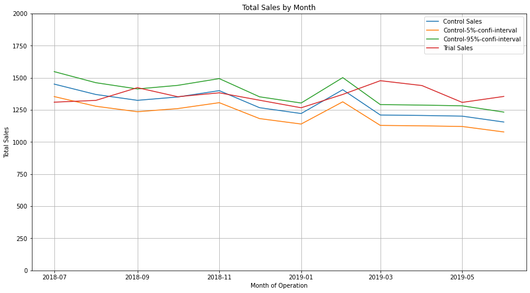

```python
plt.figure(figsize = (15, 8))
plt.plot(combinedsales)
plt.title('Total Sales by Month')
plt.xlabel('Month of Operation')
plt.ylabel('Total Sales')
plt.legend(['Control Sales', 'Control-5%-confi-interval', 'Control-95%-confi-interval', 'Trial Sales'])

# Set new y-axis limit
plt.ylim((0, 2000))

# Highlight trial period
#plt.axvspan(*mdates.datestr2num(['2019-02-01', '2019-04-01']), color = 'grey', alpha = 0.2)

# Set grid
plt.grid()
plt.show()
```

The results show that the trial in store 88 is significantly different to its control store in the trial period as the trial store performance lies outside of the 5% to 95% confidence interval of the control store in two of the three trial months.

```python
#Let's have a look at assessing this for number of customers as well.
# This would be a repeat of the steps before for total sales

trial_customers = preTrialMeasures.loc[preTrialMeasures['store_type'] == 'Trial Store' , 'CUSTOMERS'].sum()
control_customers = preTrialMeasures.loc[preTrialMeasures['store_type'] == 'Control Store', 'CUSTOMERS'].sum()
scalingFactorCustomers = trial_customers / control_customers
scalingFactorCustomers
```

```
0.9943502824858758
```

```python
scaledControlCustomers = measures
scaledControlCustomers = scaledControlCustomers.loc[scaledControlCustomers['STORE_NBR'] == control_store]
scaledControlCustomers['controlCustomers'] = scaledControlCustomers['CUSTOMERS'] * scalingFactorCustomers
scaledControlCustomers.head(3)
```

|  | STORE_NBR | Year_Month | TOT_SALES | CUSTOMERS | PROD_QTY | Price_Per_Unit | Chip_Per_Txn | Txn_Per_Cust | TransactionMonth | controlCustomers |
| --- | --- | --- | --- | --- | --- | --- | --- | --- | --- | --- |
| 2700 | 237 | 201807 | 1448.4 | 128 | 324 | 4.470370 | 2.000000 | 1.265625 | 2018-07-01 | 127.276836 |
| 2701 | 237 | 201808 | 1367.8 | 135 | 313 | 4.369968 | 1.896970 | 1.222222 | 2018-08-01 | 134.237288 |
| 2702 | 237 | 201809 | 1322.2 | 126 | 299 | 4.422074 | 2.006711 | 1.182540 | 2018-09-01 | 125.288136 |

```python
# Create 'percentageDiff' dataframe
percentageDiff = scaledControlCustomers[['Year_Month', 'controlCustomers']]
percentageDiff.reset_index(drop = True, inplace = True)

# Concatenate with trial store 'nCustomers'
trialCustomers = measures.loc[measures['STORE_NBR'] == trial_store, 'CUSTOMERS']
trialCustomers.reset_index(drop = True, inplace = True)
percentageDiff = pd.concat([percentageDiff, trialCustomers], axis = 1)
percentageDiff.rename(columns = {'CUSTOMERS': 'trialCustomers'}, inplace = True)


# Calculate percentage difference and put it in a new column

percentageDiff['percentageDiff'] = abs(percentageDiff.controlCustomers - percentageDiff.trialCustomers) / percentageDiff.controlCustomers

percentageDiff.head(3)
```

|  | Year_Month | controlCustomers | trialCustomers | percentageDiff |
| --- | --- | --- | --- | --- |
| 0 | 201807 | 127.276836 | 129 | 0.013539 |
| 1 | 201808 | 134.237288 | 131 | 0.024116 |
| 2 | 201809 | 125.288136 | 124 | 0.010281 |

```python
controlCustomers = scaledControlCustomers.loc[:, ['TransactionMonth', 'controlCustomers']]
controlCustomers.set_index('TransactionMonth', inplace = True)
controlCustomers.rename(columns = {'controlCustomers': 'Control Customers'}, inplace = True)
print(controlCustomers.head(3))

trialCustomers = measures.loc[measures['STORE_NBR'] == trial_store, ['TransactionMonth', 'CUSTOMERS']]
trialCustomers.set_index('TransactionMonth', inplace = True)
trialCustomers.rename(columns = {'CUSTOMERS': 'Trial Customers'}, inplace = True)
print(trialCustomers.head(3))
```

```
                  Control Customers
TransactionMonth
2018-07-01               127.276836
2018-08-01               134.237288
2018-09-01               125.288136
                  Trial Customers
TransactionMonth
2018-07-01                    129
2018-08-01                    131
2018-09-01                    124
```

```python
controlCustomers['Control 5% Confidence Interval'] = controlCustomers['Control Customers'] * (1 - stdDev*2)
controlCustomers['Control 95% Confidence Interval'] = controlCustomers['Control Customers'] * (1 + stdDev*2)
controlCustomers.head(3)
```

| TransactionMonth | Control Customers | Control 5% Confidence Interval | Control 95% Confidence Interval |
| --- | --- | --- | --- |
| 2018-07-01 | 127.276836 | 118.757468 | 135.796205 |
| 2018-08-01 | 134.237288 | 125.252017 | 143.222560 |
| 2018-09-01 | 125.288136 | 116.901882 | 133.674389 |

```python
combineCustomers = pd.concat([controlCustomers, trialCustomers], axis = 1)
combineCustomers.head(3)
```

| TransactionMonth | Control Customers | Control 5% Confidence Interval | Control 95% Confidence Interval | Trial Customers |
| --- | --- | --- | --- | --- |
| 2018-07-01 | 127.276836 | 118.757468 | 135.796205 | 129 |
| 2018-08-01 | 134.237288 | 125.252017 | 143.222560 | 131 |
| 2018-09-01 | 125.288136 | 116.901882 | 133.674389 | 124 |

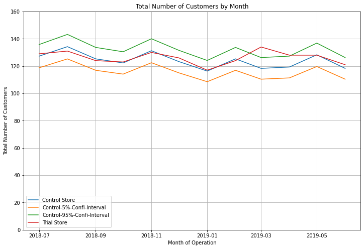

```python
#visualizing
plt.figure(figsize = (12, 8))
plt.plot(combineCustomers)
plt.title('Total Number of Customers by Month')
plt.xlabel('Month of Operation')
plt.ylabel('Total Number of Customers')
plt.legend(['Control Store', 'Control-5%-Confi-Interval', 'Control-95%-Confi-Interval', 'Trial Store'])

plt.ylim((0, 160))
# Highlight trial period
#plt.axvspan(*mdates.datestr2num(['2019-02-01', '2019-04-01']), color = 'grey', alpha = 0.2)

# Set grid
plt.grid()
plt.show()
```

Total number of customers in the trial period for the trial store is significantly higher than the control store for two out of three months, which indicates a positive trial effect.

## Conclusion

We've found control stores 233, 155, 237 for trial stores 77, 86 and 88 respectively.

The results for trial stores 77 and 88 during the trial period show a significant difference in at least two of the three trial months but this is not the case for trial store 86. We can check with the client if the implementation of the trial was different in trial store 86 but overall, the trial shows a significant increase in sales. Now that we have finished our analysis, we can prepare our presentation to the Category Manager. Page